# IODS course project

# Logistic regression excercise

The data in this chapter is combined from two data-sets in a freely available [zip file](https://archive.ics.uci.edu/ml/machine-learning-databases/00356/). The datafiles contain students’ family background and free time activity information as well as first, second and final grades in mathematics and portugese. List of the variable names will be available under this chapter. More information on the contents of the file can be found [here](https://archive.ics.uci.edu/ml/datasets/STUDENT+ALCOHOL+CONSUMPTION). Variables “school”, “sex”, “age”, “address”, “famsize”, “Pstatus”, “Medu”, “Fedu”, “Mjob”, “Fjob”, “reason”, “nursery”,“internet” were used as identifiers for joining the data. Only the observations present in both datasets were accepted. The variables not used for joining the two data have been combined by averaging. Average of weekday and weekend alcohol consuption was produced into variable “alc_use”, and logical variable “high_use” is true for students with higher than 2 value in the “alc_use”.

```r
colnames(alc)
```

```
##  [1] "school"     "sex"        "age"        "address"    "famsize"
##  [6] "Pstatus"    "Medu"       "Fedu"       "Mjob"       "Fjob"
## [11] "reason"     "nursery"    "internet"   "guardian"   "traveltime"
## [16] "studytime"  "failures"   "schoolsup"  "famsup"     "paid"
## [21] "activities" "higher"     "romantic"   "famrel"     "freetime"
## [26] "goout"      "Dalc"       "Walc"       "health"     "absences"
## [31] "G1"         "G2"         "G3"         "alc_use"    "high_use"
```

Age (“age”) is definitely interesting variable concerning alchohol consumption. I imagine that very young students are less likely to consume high amounts of alcohol than older students. Sex of the student (“sex”) might show cultural influence. I imagine male students are more likely to consume high amounts of alcohol. I also assume that mother’s job (“Mjob”) or father’s job (“Fjob”) in health care related sector will reduce changes for high alcohol consumption. I will now make a analysis data set containing these variables and the logical variable for high alcohol use (“high_use”) and explore the disributions of the chosen variables.

```r
# Selecting the variables
analysis_variables <- c("age","sex","Mjob","Fjob","high_use")
analysis <- select(alc, one_of(analysis_variables))

# Summary
summary(analysis)
```

```
##       age        sex           Mjob           Fjob      high_use
##  Min.   :15.00   F:198   at_home : 53   at_home : 16   Mode :logical
##  1st Qu.:16.00   M:184   health  : 33   health  : 17   FALSE:270
##  Median :17.00           other   :138   other   :211   TRUE :112
##  Mean   :16.59           services: 96   services:107   NA's :0
##  3rd Qu.:17.00           teacher : 62   teacher : 31
##  Max.   :22.00
```

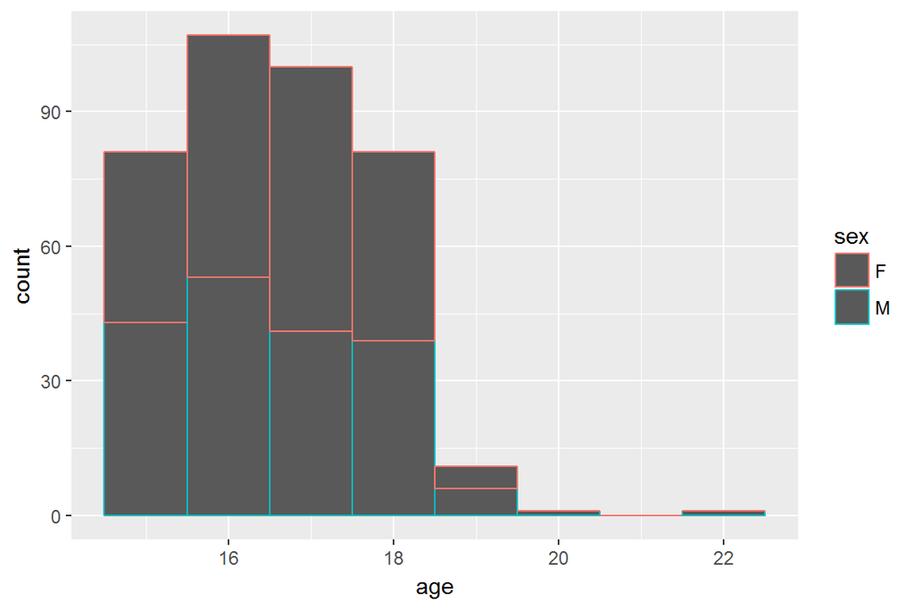

```r
# Graphical disributions of the non-logical variables
p1a <- ggplot(analysis, aes(x = age, col = sex))
p1 <- p1a + geom_histogram(binwidth=1)
p2a <- ggplot(analysis, aes(x = Mjob, col = sex))
p2 <- p2a + geom_bar()
p3a <- ggplot(analysis, aes(x = Fjob, col = sex))
p3 <- p3a + geom_bar()
p1 # printout
```

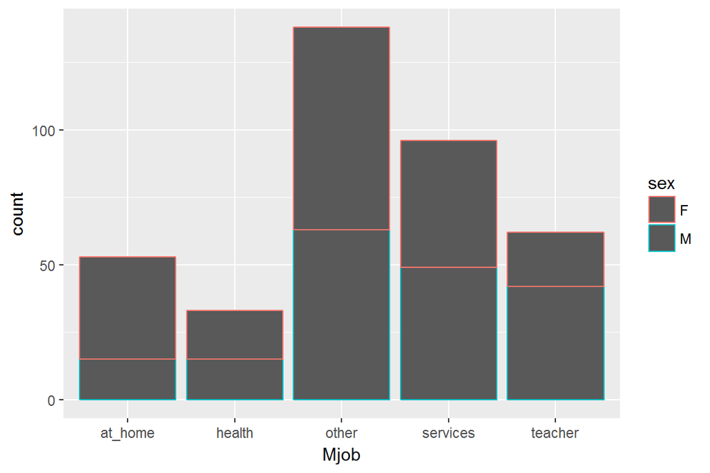

```r
p2 # printout
```

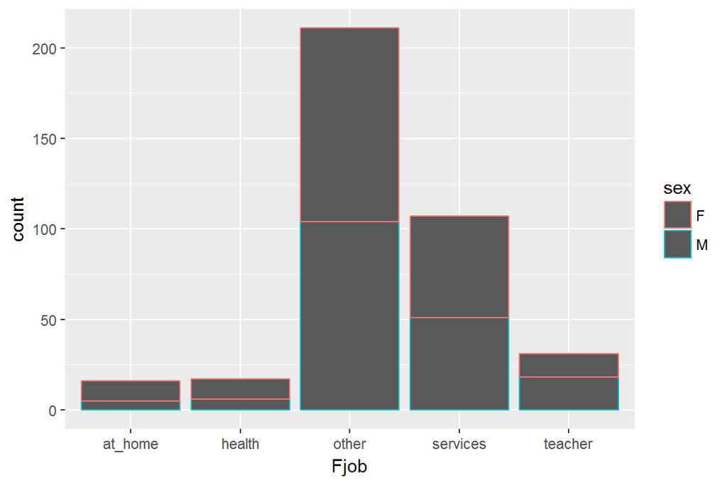

```r
p3 # printout
```

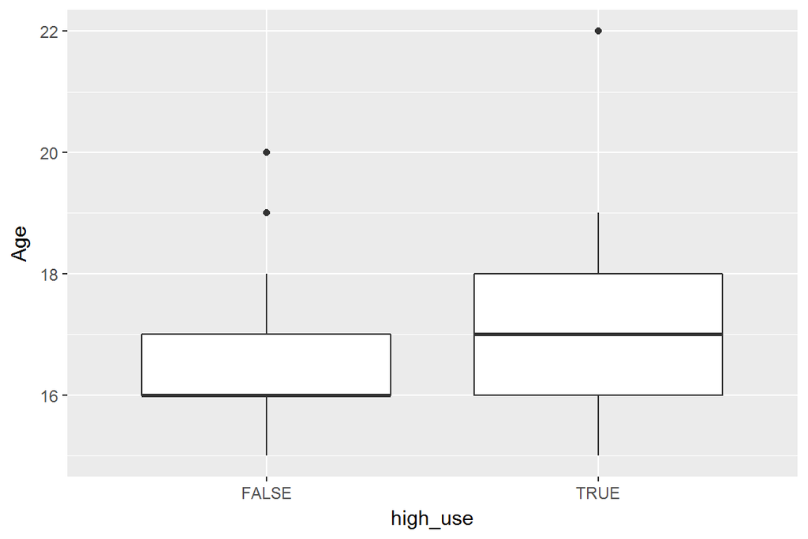

```r
g1 <- ggplot(analysis, aes(x = high_use, y = age))
g1 + geom_boxplot() + ylab("Age")
```

```r
table(Age = analysis$age, high_use = analysis$high_use) %>% addmargins()
```

```
##      high_use
## Age   FALSE TRUE Sum
##   15     63   18  81
##   16     79   28 107
##   17     65   35 100
##   18     55   26  81
##   19      7    4  11
##   20      1    0   1
##   22      0    1   1
##   Sum   270  112 382
```

```r
table(Sex = analysis$sex, high_use = analysis$high_use) %>% addmargins()
```

```
##      high_use
## Sex   FALSE TRUE Sum
##   F     157   41 198
##   M     113   71 184
##   Sum   270  112 382
```

```r
table(MotherJob = analysis$Mjob, high_use = analysis$high_use) %>% addmargins()
```

```
##           high_use
## MotherJob  FALSE TRUE Sum
##   at_home     36   17  53
##   health      23   10  33
##   other      101   37 138
##   services    67   29  96
##   teacher     43   19  62
##   Sum        270  112 382
```

```r
table(FatherJob = analysis$Fjob, high_use = analysis$high_use) %>% addmargins()
```

```
##           high_use
## FatherJob  FALSE TRUE Sum
##   at_home     14    2  16
##   health      13    4  17
##   other      149   62 211
##   services    69   38 107
##   teacher     25    6  31
##   Sum        270  112 382
```

The boxplot shows slighly higher ages for the high alcohol consuming students, but the range of ages is maybe too narrow to notice a clear difference (I was expecting larger distribution of ages, and younger students might show this trend better). As expected, the male students use high amounts of alcohol almost twice as often as female students. According to the assumption, The students might use less alcohol if their fathers work in healtcare or teaching sector, or are home compared to students whose fathers work in servises or other sectors. Unexpectedly, the mother’s job does not show similar trend. Instead, the children of mothers who stay at home might have slight tendency to consume more alcohol than other students. Let us make a logistic regression model out of the findings here. The variables describing parents’ work will be mutated to logical variables Mhome (mother at home) and Func (father has a uncommon work status among fathers) to allow meaningful use of the logistic regression model.

```r
# Mutations of the data
analysis <- mutate(analysis, Func = (Fjob=="at_home"|Fjob=="health"|Fjob=="teacher") )
analysis <- mutate(analysis, Mhome = (Mjob=="at_home") )
str(analysis)
```

```
## 'data.frame':    382 obs. of  7 variables:
##  $ age     : int  18 17 15 15 16 16 16 17 15 15 ...
##  $ sex     : Factor w/ 2 levels "F","M": 1 1 1 1 1 2 2 1 2 2 ...
##  $ Mjob    : Factor w/ 5 levels "at_home","health",..: 1 1 1 2 3 4 3 3 4 3 ...
##  $ Fjob    : Factor w/ 5 levels "at_home","health",..: 5 3 3 4 3 3 3 5 3 3 ...
##  $ high_use: logi  FALSE FALSE TRUE FALSE FALSE FALSE ...
##  $ Func    : logi  TRUE FALSE FALSE FALSE FALSE FALSE ...
##  $ Mhome   : logi  TRUE TRUE TRUE FALSE FALSE FALSE ...
```